```python
import numpy as np
import pandas as pd
import seaborn as sns
import matplotlib.pyplot as plt
from sklearn.preprocessing import LabelEncoder, PolynomialFeatures
from sklearn.model_selection import train_test_split, StratifiedKFold, cross_val_score, GridSearchCV
from sklearn.linear_model import LogisticRegression
from sklearn.neighbors import KNeighborsClassifier
from sklearn.tree import DecisionTreeClassifier
from sklearn.svm import SVC
from sklearn.ensemble import GradientBoostingClassifier, RandomForestClassifier
from sklearn.linear_model import LinearRegression
from sklearn.metrics import accuracy_score, classification_report, mean_squared_error, r2_score
from imblearn.over_sampling import SMOTE
from scipy import stats
from sklearn.model_selection import train_test_split
from sklearn.linear_model import LinearRegression
from dmba import regressionSummary
from dmba import backward_elimination, stepwise_selection
from dmba import adjusted_r2_score, AIC_score
import statsmodels.formula.api as sm
from sklearn.metrics import confusion_matrix, accuracy_score, classification_report
from sklearn.tree import DecisionTreeClassifier, plot_tree
%matplotlib inline
from utils import *

import warnings
```

# Campus Placement Dataset Analysis

##### Dataset

```python
col_names = [
    "SerialNumber",
    "Gender",
    "LowerSecondarySchollGrade%",
    "LowerSecondarySchollBoard",
    "HigherSecondarySchollGrade%",
    "HigherSecondarySchollBoard",
    "HigherSecondarySchollSpecialization",
    "DegreeGrade%",
    "DegreeSpecialization",
    "WorkExperience",
    "EmployabilityTestGrade%",
    "MBASpecialization",
    "MBAGrade%",
    "PlacementStatus",
    "Salary"
]
data = pd.read_csv("Placement_Data_Full_Class.csv", names=col_names, header=0)
data.head(10)
```

|  | SerialNumber | Gender | LowerSecondarySchollGrade% | LowerSecondarySchollBoard | HigherSecondarySchollGrade% | HigherSecondarySchollBoard | HigherSecondarySchollSpecialization | DegreeGrade% | DegreeSpecialization | WorkExperience | EmployabilityTestGrade% | MBASpecialization | MBAGrade% | PlacementStatus | Salary |
| --- | --- | --- | --- | --- | --- | --- | --- | --- | --- | --- | --- | --- | --- | --- | --- |
| 0 | 1 | M | 67.00 | Others | 91.00 | Others | Commerce | 58.00 | Sci&Tech | No | 55.00 | Mkt&HR | 58.80 | Placed | 270000.0 |
| 1 | 2 | M | 79.33 | Central | 78.33 | Others | Science | 77.48 | Sci&Tech | Yes | 86.50 | Mkt&Fin | 66.28 | Placed | 200000.0 |
| 2 | 3 | M | 65.00 | Central | 68.00 | Central | Arts | 64.00 | Comm&Mgmt | No | 75.00 | Mkt&Fin | 57.80 | Placed | 250000.0 |
| 3 | 4 | M | 56.00 | Central | 52.00 | Central | Science | 52.00 | Sci&Tech | No | 66.00 | Mkt&HR | 59.43 | Not Placed | NaN |
| 4 | 5 | M | 85.80 | Central | 73.60 | Central | Commerce | 73.30 | Comm&Mgmt | No | 96.80 | Mkt&Fin | 55.50 | Placed | 425000.0 |
| 5 | 6 | M | 55.00 | Others | 49.80 | Others | Science | 67.25 | Sci&Tech | Yes | 55.00 | Mkt&Fin | 51.58 | Not Placed | NaN |
| 6 | 7 | F | 46.00 | Others | 49.20 | Others | Commerce | 79.00 | Comm&Mgmt | No | 74.28 | Mkt&Fin | 53.29 | Not Placed | NaN |
| 7 | 8 | M | 82.00 | Central | 64.00 | Central | Science | 66.00 | Sci&Tech | Yes | 67.00 | Mkt&Fin | 62.14 | Placed | 252000.0 |
| 8 | 9 | M | 73.00 | Central | 79.00 | Central | Commerce | 72.00 | Comm&Mgmt | No | 91.34 | Mkt&Fin | 61.29 | Placed | 231000.0 |
| 9 | 10 | M | 58.00 | Central | 70.00 | Central | Commerce | 61.00 | Comm&Mgmt | No | 54.00 | Mkt&Fin | 52.21 | Not Placed | NaN |

First thing to notice here is that if the status is "Not Placed", it seems that the salary will be NaN. Just a remainder to not treat it as missing data. It will be necessary to check if there is someone "Placed" with a NaN salary. Some encoding will be necessary for the categorical data.

The first column seems to be just an ID. It will be droped.

Let's take a better look at the features information

## Categorical features

##### Gender

```python
data["Gender"].value_counts()
```

```
M    139
F     76
Name: Gender, dtype: int64
```

###### Lower Secondary Education

```python
data["LowerSecondarySchollBoard"].value_counts()
```

```
Central    116
Others      99
Name: LowerSecondarySchollBoard, dtype: int64
```

##### Higher Secondary Education

```python
data["HigherSecondarySchollBoard"].value_counts()
```

```
Others     131
Central     84
Name: HigherSecondarySchollBoard, dtype: int64
```

###### Specialization

```python
data["HigherSecondarySchollSpecialization"].value_counts()
```

```
Commerce    113
Science      91
Arts         11
Name: HigherSecondarySchollSpecialization, dtype: int64
```

##### Degree Specialization

```python
data["DegreeSpecialization"].value_counts()
```

```
Comm&Mgmt    145
Sci&Tech      59
Others        11
Name: DegreeSpecialization, dtype: int64
```

##### Work Experience

```python
data["WorkExperience"].value_counts()
```

```
No     141
Yes     74
Name: WorkExperience, dtype: int64
```

##### Placement Status

```python
data["PlacementStatus"].value_counts()
```

```
Placed        148
Not Placed     67
Name: PlacementStatus, dtype: int64
```

## Exploratory Analysis

Descrption

```python
data.describe()
```

|  | SerialNumber | LowerSecondarySchollGrade% | HigherSecondarySchollGrade% | DegreeGrade% | EmployabilityTestGrade% | MBAGrade% | Salary |
| --- | --- | --- | --- | --- | --- | --- | --- |
| count | 215.000000 | 215.000000 | 215.000000 | 215.000000 | 215.000000 | 215.000000 | 148.000000 |
| mean | 108.000000 | 67.303395 | 66.333163 | 66.370186 | 72.100558 | 62.278186 | 288655.405405 |
| std | 62.209324 | 10.827205 | 10.897509 | 7.358743 | 13.275956 | 5.833385 | 93457.452420 |
| min | 1.000000 | 40.890000 | 37.000000 | 50.000000 | 50.000000 | 51.210000 | 200000.000000 |
| 25% | 54.500000 | 60.600000 | 60.900000 | 61.000000 | 60.000000 | 57.945000 | 240000.000000 |
| 50% | 108.000000 | 67.000000 | 65.000000 | 66.000000 | 71.000000 | 62.000000 | 265000.000000 |
| 75% | 161.500000 | 75.700000 | 73.000000 | 72.000000 | 83.500000 | 66.255000 | 300000.000000 |
| max | 215.000000 | 89.400000 | 97.700000 | 91.000000 | 98.000000 | 77.890000 | 940000.000000 |

```python
data.isnull().sum()
```

```
SerialNumber                            0
Gender                                  0
LowerSecondarySchollGrade%              0
LowerSecondarySchollBoard               0
HigherSecondarySchollGrade%             0
HigherSecondarySchollBoard              0
HigherSecondarySchollSpecialization     0
DegreeGrade%                            0
DegreeSpecialization                    0
WorkExperience                          0
EmployabilityTestGrade%                 0
MBASpecialization                       0
MBAGrade%                               0
PlacementStatus                         0
Salary                                 67
dtype: int64
```

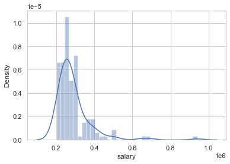

```python
import os
for dirname, _, filenames in os.walk('/kaggle/input'):
    for filename in filenames:
        print(os.path.join(dirname, filename))
import seaborn as sns
from matplotlib import pyplot as plt

dataset = pd.read_csv('Placement_Data_Full_Class.csv')

sns.set(style="whitegrid")
sns.distplot(dataset.salary)
```

We will fill missing salaries with 0s as they represent students who have not got placement offer.

```python
dataset['salary']=dataset['salary'].fillna(0)
data.drop("SerialNumber", axis=1, inplace=True)
```

#### Let's analyse the distribution of the PlacementStatus column

```
Placed 68.84 % of the dataset
Not placed 31.16 % of the dataset
```

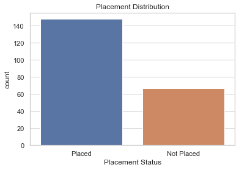

```python
plot = sns.countplot(x="PlacementStatus", data=data)
plt.title("Placement Distribution")
plt.xlabel("Placement Status")
plot.get_figure().savefig("images/PlacementStatus.png")

print('Placed', round(data["PlacementStatus"].value_counts()[0]/len(data) * 100,2), '% of the dataset')
print('Not placed', round(data["PlacementStatus"].value_counts()[1]/len(data) * 100,2), '% of the dataset')
```

```python
data[data["PlacementStatus"] == "Not Placed"]["PlacementStatus"].value_counts()
```

```
Not Placed    67
Name: PlacementStatus, dtype: int64
```

### Converting rupees to US

$ (1 rupee = $ 0.013)

```python
dataset.index = dataset['sl_no']
dataset.drop('sl_no', axis=1, inplace=True)

dataset['salary'] = dataset['salary'] * 0.013
dataset.head(10)
```

| sl_no | gender | ssc_p | ssc_b | hsc_p | hsc_b | hsc_s | degree_p | degree_t | workex | etest_p | specialisation | mba_p | status | salary |
| --- | --- | --- | --- | --- | --- | --- | --- | --- | --- | --- | --- | --- | --- | --- |
| 1 | M | 67.00 | Others | 91.00 | Others | Commerce | 58.00 | Sci&Tech | No | 55.00 | Mkt&HR | 58.80 | Placed | 3510.0 |
| 2 | M | 79.33 | Central | 78.33 | Others | Science | 77.48 | Sci&Tech | Yes | 86.50 | Mkt&Fin | 66.28 | Placed | 2600.0 |
| 3 | M | 65.00 | Central | 68.00 | Central | Arts | 64.00 | Comm&Mgmt | No | 75.00 | Mkt&Fin | 57.80 | Placed | 3250.0 |
| 4 | M | 56.00 | Central | 52.00 | Central | Science | 52.00 | Sci&Tech | No | 66.00 | Mkt&HR | 59.43 | Not Placed | 0.0 |
| 5 | M | 85.80 | Central | 73.60 | Central | Commerce | 73.30 | Comm&Mgmt | No | 96.80 | Mkt&Fin | 55.50 | Placed | 5525.0 |
| 6 | M | 55.00 | Others | 49.80 | Others | Science | 67.25 | Sci&Tech | Yes | 55.00 | Mkt&Fin | 51.58 | Not Placed | 0.0 |
| 7 | F | 46.00 | Others | 49.20 | Others | Commerce | 79.00 | Comm&Mgmt | No | 74.28 | Mkt&Fin | 53.29 | Not Placed | 0.0 |
| 8 | M | 82.00 | Central | 64.00 | Central | Science | 66.00 | Sci&Tech | Yes | 67.00 | Mkt&Fin | 62.14 | Placed | 3276.0 |
| 9 | M | 73.00 | Central | 79.00 | Central | Commerce | 72.00 | Comm&Mgmt | No | 91.34 | Mkt&Fin | 61.29 | Placed | 3003.0 |
| 10 | M | 58.00 | Central | 70.00 | Central | Commerce | 61.00 | Comm&Mgmt | No | 54.00 | Mkt&Fin | 52.21 | Not Placed | 0.0 |

## Gender based analysis

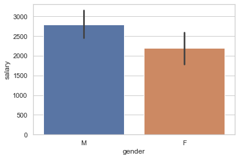

```python
sns.barplot(x = dataset['gender'],y = dataset['salary'])
```

###### Swarmplot of Gender VS Salary

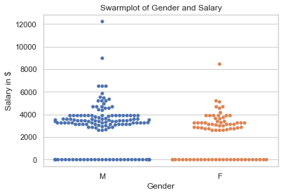

```python
_ = sns.swarmplot(x='gender', y='salary', data=dataset)
_ = plt.xlabel('Gender')
_ = plt.ylabel('Salary in $')
_ = plt.title('Swarmplot of Gender and Salary')
plt.show()
```

```python
print('Men', round(data["Gender"].value_counts()[0]/len(data) * 100,2), '% of the dataset')
print('Women', round(data["Gender"].value_counts()[1]/len(data) * 100,2), '% of the dataset')
```

```
Men 64.65 % of the dataset
Women 35.35 % of the dataset
```

##### Lower Secondary Grade Based

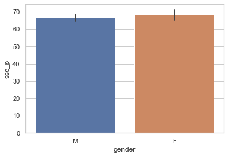

```python
sns.barplot(x = dataset['gender'],y = dataset['ssc_p'])
```

##### Higher Secondary Grade Based

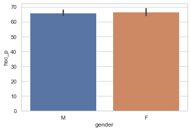

```python
sns.barplot(x = dataset['gender'],y = dataset['hsc_p'])
```

##### Undergraduation Degree Based

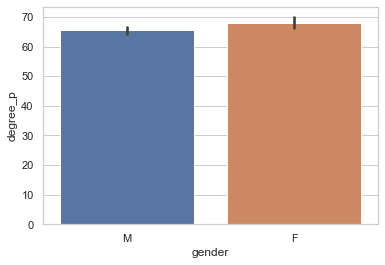

```python
sns.barplot(x = dataset['gender'],y = dataset['degree_p'])
```

##### Specialization

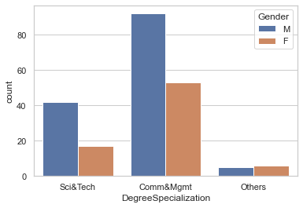

```python
sns.countplot(x="DegreeSpecialization", hue="Gender", data=data)
```

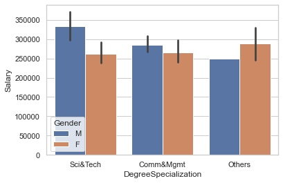

```python
sns.barplot(x="DegreeSpecialization", y="Salary", hue="Gender", data=data)
```

##### Post Graduation Based

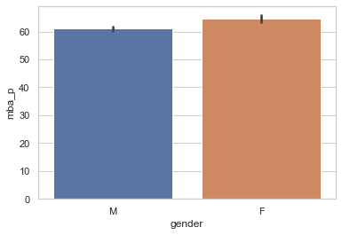

```python
sns.barplot(x = dataset['gender'],y = dataset['mba_p'])
```

##### Specialisation

MBA Specialisation

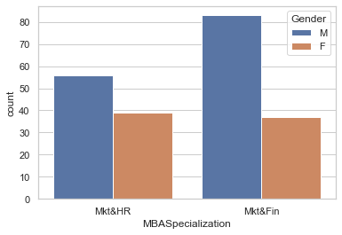

```python
# MBASpecialization
sns.countplot(x="MBASpecialization", hue="Gender", data=data)
```

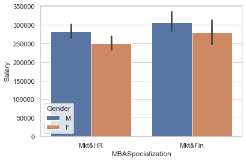

```python
sns.barplot(x="MBASpecialization", y="Salary", hue="Gender", data=data)
```

### Mean

```
The mean salary of Male is 2796.0 while Female is 2195.0
The median salary of Male is 3250.0 while Female is 2808.0
```

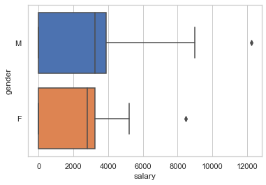

```python
sns.boxplot(x = dataset['salary'],y= dataset['gender'],saturation=1)
mean_of_both=round(dataset['salary'].groupby(dataset['gender']).mean())
median_both=round(dataset['salary'].groupby(dataset['gender']).median())
print('The mean salary of Male is {} while Female is {}'.format(mean_of_both[1],mean_of_both[0]))
print('The median salary of Male is {} while Female is {}'.format(median_both[1],median_both[0]))
plt.show()
```

#### Observation

Men are getting higher salaries than women even when women scored higher percentages during their school and college degrees. 1. The Range of salary is high for boys with the median of 2.5 Lakhs per annum 2. The Median salary for girls is 2.1 Lakhs per annum 3. The highest package is offered to a boy which is nearly to 10 Lakhs per annum 4. The highest package offered for girls is near to 7 Lakhs per annum Women that came from men-dominated fields receive lower salaries, but receive higher salaries if they came from "Others" fields. However, the amount of data from the "Others" field is not large enough to give a conclusive answer, more data would be required.

## Placement status based analysis

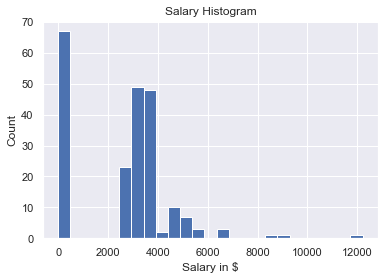

```python
sns.set()
_ = plt.hist(dataset['salary'], bins=25)
_ = plt.xlabel('Salary in $')
_ = plt.ylabel('Count')
_ = plt.title('Salary Histogram')
plt.show()
```

##### Lower Secondary Education Based

Swarmplot of Secondary Education and Salary

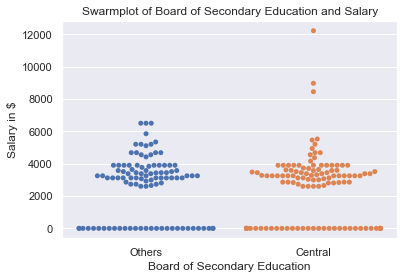

```python
_ = sns.swarmplot(x='ssc_b', y='salary', data=dataset)
_ = plt.xlabel('Board of Secondary Education')
_ = plt.ylabel('Salary in $')
_ = plt.title('Swarmplot of Board of Secondary Education and Salary')
plt.show()
```

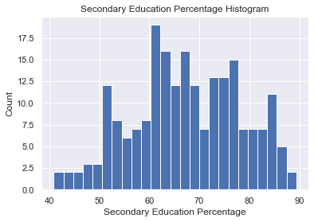

```python
_ = plt.hist(dataset['ssc_p'], bins=25)
_ = plt.xlabel('Secondary Education Percentage')
_ = plt.ylabel('Count')
_ = plt.title('Secondary Education Percentage Histogram')
plt.show()
```

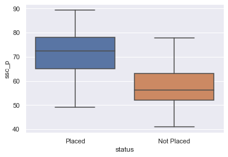

```python
sns.boxplot(x = dataset['status'], y = dataset['ssc_p'])
```

##### Higher Secondary Education Based

Swarmplot of Higher Education and Salary

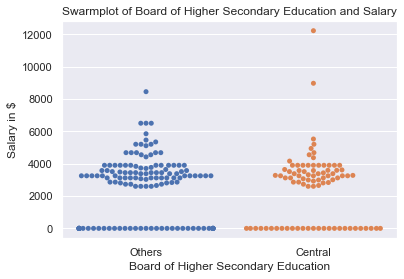

```python
_ = sns.swarmplot(x='hsc_b', y='salary', data=dataset)
_ = plt.xlabel('Board of Higher Secondary Education')
_ = plt.ylabel('Salary in $')
_ = plt.title('Swarmplot of Board of Higher Secondary Education and Salary')
plt.show()
```

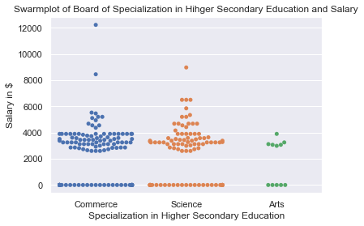

```python
_ = sns.swarmplot(x='hsc_s', y='salary', data=dataset)
_ = plt.xlabel('Specialization in Higher Secondary Education')
_ = plt.ylabel('Salary in $')
_ = plt.title('Swarmplot of Board of Specialization in Hihger Secondary Education and Salary')
plt.show()
```

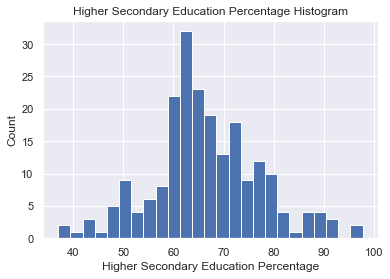

```python
_ = plt.hist(dataset['hsc_p'], bins=25)
_ = plt.xlabel('Higher Secondary Education Percentage')
_ = plt.ylabel('Count')
_ = plt.title('Higher Secondary Education Percentage Histogram')
plt.show()
```

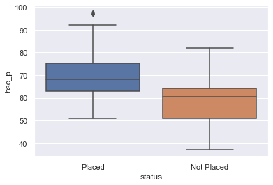

```python
sns.boxplot(x = dataset['status'], y = dataset['hsc_p'])
```

##### Undergraduate Degree Based

Swarmplot Of Undergraduate Education field and salary

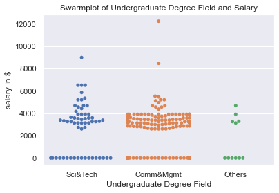

```python
_ = sns.swarmplot(x='degree_t', y='salary', data=dataset)
_ = plt.xlabel('Undergraduate Degree Field')
_ = plt.ylabel('salary in $')
_ = plt.title('Swarmplot of Undergraduate Degree Field and Salary')
plt.show()
```

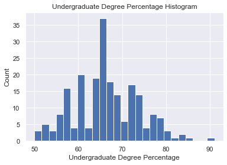

```python
_ = plt.hist(dataset['degree_p'], bins=25)
_ = plt.xlabel('Undergraduate Degree Percentage')
_ = plt.ylabel('Count')
_ = plt.title('Undergraduate Degree Percentage Histogram')
plt.show()
```

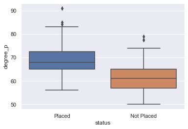

```python
sns.boxplot(x = dataset['status'], y = dataset['degree_p'])
```

Swarmplot of Work Experience and Salary

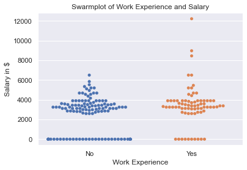

```python
_ = sns.swarmplot(x='workex', y='salary', data=dataset)
_ = plt.xlabel('Work Experience')
_ = plt.ylabel('Salary in $')
_ = plt.title('Swarmplot of Work Experience and Salary')
plt.show()
```

##### Post Graduation Based

Swarmplot Of Post graduation and salary

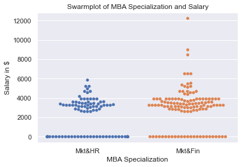

```python
_ = sns.swarmplot(x='specialisation', y='salary', data=dataset)
_ = plt.xlabel('MBA Specialization')
_ = plt.ylabel('Salary in $')
_ = plt.title('Swarmplot of MBA Specialization and Salary')
plt.show()
```

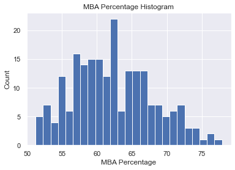

```python
_ = plt.hist(dataset['mba_p'], bins=25)
_ = plt.xlabel('MBA Percentage')
_ = plt.ylabel('Count')
_ = plt.title('MBA Percentage Histogram')
plt.show()
```

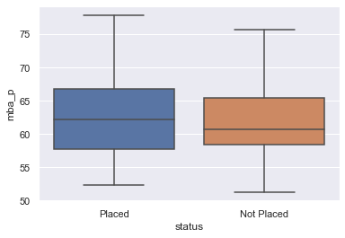

```python
sns.boxplot(x = dataset['status'], y = dataset['mba_p'])
```

# Employment Test Percentage

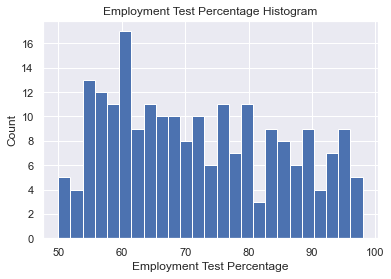

```python
_ = plt.hist(dataset['etest_p'], bins=25)
_ = plt.xlabel('Employment Test Percentage')
_ = plt.ylabel('Count')
_ = plt.title('Employment Test Percentage Histogram')
plt.show()
```

### Observation

Students with higher percentages/better academic results were able to perform well during placements compared to those who had relatively lower academic results